# Act Report

Blog-style post of an analysis for a Udacity project. Created by: Alan Glasper, March 10th, 2019

```python
# https://stackoverflow.com/questions/27934885/\
# how-to-hide-code-from-cells-in-ipython-notebook-visualized-with-nbviewer
from IPython.display import HTML

display(HTML('''<script>
code_show=true;
function code_toggle() {
 if (code_show){
 $('div.input').hide();
 } else {
 $('div.input').show();
 }
 code_show = !code_show
}
$( document ).ready(code_toggle);
</script>
<form action="javascript:code_toggle()">\
<input type="submit" value="Click here to toggle on/off the raw code.">\
</form>'''))
```

# Can a machine learn to identify a good dog?

[We Rate Dogs](https://twitter.com/dog_rates) is a hit Twitter account where pictures of (mostly!) dogs are posted with a special rating. With nearly 8 million followers, they have even turned their whimsical fun into a board game (available from April 2019). Dogs are referred to with charming 'stages' (an infant 'pupper' grows up to an adolescent 'puppo' which eventually becomes an adult 'doggo' and maybe even a fluffy 'floofer' - not really a stage but could apply to any dog) and rated with contagious enthusiasm out of 10, and usually 11 or 12 or 13 or more out of 10 because [they're good dogs, brent](http://knowyourmeme.com/memes/theyre-good-dogs-brent).

As part of a Udacity project, with data kindly provided to Udacity by We Rate Dogs, I downloaded their Twitter archive (from their kickoff in November 2015 until August 2017) and combined the data there with results from a Machine Learning Neural Network that attempted to predict the breed of the dog (or some other kind of object) in their pictures.

As you can imagine, there are all sorts of difficulties for a machine to distinguish specific breeds of dog from other objects in images that often involve toys, clothing, household items and weird situations. I'll show you some of the results from my analysis of the data and we'll look at some examples where the machine had difficulties finding a dog often hiding in plain sight!

For each of the original tweets, the machine made three "predictions" (read: guesses) of what is in the picture and provided its own confidence as a percentage for each prediction (e.g. "I'm 75% sure this is a Dalmatian, 20% sure this is a Teddy, and 1% sure this is a Steam Locomotive"). In this analysis, I am looking at the top prediction confidence and also comparing the ratings, retweet and favorite counts for those tweets that also named one of the dog stages (floofer, doggo, puppo, pupper) to see if some stages are more popular than others. Do young puppers really get all the attention? Later we'll look at some of the individual predictions that went wrong. So you can always scroll past the graphs and get straight to the cuties!

```python
import numpy as np
import pandas as pd
import matplotlib.pyplot as plt
# The functions used here need at least version 0.9.0 of Seaborn.
# An exception is raised if this is not the case.
import seaborn as sns
from IPython.display import Image
from IPython.core.display import HTML
from pandas.api.types import CategoricalDtype

% matplotlib inline
```

```python
# Additions to improve the presentation quality.
# In a new cell because of a problem when figsize is set
# in the same cell as matplotlib inline.
# To be sure, do all formatting in a separate cell.

# Setup the Seaborn graphics.
sns.set(font_scale=1.25)
sns.set_style("white")

# Set all following figures to a reasonable size
plt.rcParams['figure.figsize'] = [10, 5]


# https://www.dataquest.io/blog/jupyter-notebook-tips-tricks-shortcuts/
% config InlineBackend.figure_format = 'retina'
from IPython.core.interactiveshell import InteractiveShell
InteractiveShell.ast_node_interactivity = "all"

# Helper function for graphics used more than a few times.

def values_by_category(df,
                       category,
                       title1, y1, ylabel1, statistic1,
                       title2, y2, ylabel2, statistic2,
                       ylim1=None, ylim2=None,
                       ci1=None, ci2=None,
                       bar_color=None):
    """Create two bar charts with confidence intervals for each statistic.

    The function assumes the category is the first argument, followed by
    the upper continuous variable arguments, then lower continuous
    variable parameters, optional arguments to limit the y axes, optional
    arguments designed to switch off the error bars, and an optional
    color argument. Note there is no x-axis label, a design choice.
    Don't forget to 'display' the returned object.

    Args:
        (DataFrame) df: pandas DataFrame containing data to be displayed
        (string) category: name of column with the category for the x axis
        (string) title1: title for the upper graphic
        (string) y1: name of column with the category for the upper y axis
        (string) ylabel1: label for the upper graphic y axis
        (string) statistic1; statistic to apply upper, e.g. 'np.median'
        (float tuple) ylim1: a tuple of y axis limits for upper graphic
        (string) ci1: if this is provided then upper error bars are off
         - the same with suffix 2 apply to the lower graphic
    Returns:
        (FacetGrid object)  figure with two subplots
    """
    fig = plt.figure()
    ax1 = fig.add_subplot(211)
    ax1.set_title(title1)

    if(ylim1 != None):
        ax1.set(ylim=ylim1)
    ax2 = fig.add_subplot(212)
    ax2.set_title(title2)

    if(ylim2 != None):
        ax2.set(ylim=ylim2)

# The default is ci1 to be None. Any provided ci1 other than None will
# switch off the error bars. Yes, this is ugly.
    if(ci1 == None):
        g1 = sns.catplot(x=category, y=y1, kind='bar', capsize=.2,
                ax=ax1, data=df, estimator=statistic1,
                color=bar_color)
    else:
        g1 = sns.catplot(x=category, y=y1, kind='bar', capsize=.2,
                ax=ax1, data=df, estimator=statistic1, ci=None,
                color=bar_color)
# The default is ci2 to be None. Any provided ci2 other than None will
# switch off the error bars. Yes, this is ugly.

    if(ci2 == None):
        g2 = sns.catplot(x=category, y=y2, kind='bar', capsize=.2,
                ax=ax2, data=df, estimator=statistic2,
                color=bar_color)
    else:
        g2 = sns.catplot(x=category, y=y2, kind='bar', capsize=.2,
                ax=ax2, data=df, estimator=statistic2,  ci=None,
                color=bar_color)

    ax1.set_ylabel(ylabel1)
    ax2.set_ylabel(ylabel2)
    ax1.set_xlabel('')
    plt.close(g1.fig)

    ax2.set_xlabel('')
    plt.close(g2.fig)
    plt.tight_layout();

def printable_stats_table(df, category, title):
    """Create a table of stats for the category

    The table is of counts and share of total per category.

    Args:
        (DataFrame) df: pandas DataFrame containing data to be displayed
        (string) category: column name of the category
        (string) title: title of the categories in displayed table
    Returns:
        (Dataframe)  pandas DataFrame containing table
    """
    cnt = df[category].value_counts().to_frame().reset_index()
    cnt.rename(columns = {category:'Count',
                          'index':title}, inplace = True)
    proportion = df[category].value_counts() / len(df)
    pct = proportion.to_frame().reset_index()
    pct.rename(columns = {category:'Share (%)',
                     'index':title}, inplace = True)
    table_stats = pd.merge(cnt, pct, on=title)
    return(table_stats)

def display_subset_images(df, query_string, sample=None):
    """Display values and images from urls for a DataFrame subset

    The function creates a subset of a dataFrame via the query string
    and prints out the three prediction breeds and confidence levels
    followed by the image, for each tweet in the subset.
    If the optional sample parameter is set, a random sample of the size
    requested will be displayed. Note that the sample is deliberately
    not reproduceable - this allows browsing the subset.
    Don't forget to 'display' the returned output.

    Args:
        (DataFrame) df: pandas DataFrame containing data to be displayed
        (string) query_string: The query string for the subset
        (string) sample: optional number of samples to display
    Returns:
        Output combining printing with images that is to be displayed.
    """
    if sample == None:
        for index, row in df.query(
            query_string).iterrows():
            print('Tweet identifier: {}\n#1: {} ({:.0%}) -> #2: {} \
            ({:.0%}) -> #3: {} ({:.0%})'.format(
                row['tweet_id'],
                row['predict_1_breed'], row['predict_1_confidence'],
                row['predict_2_breed'], row['predict_2_confidence'],
                row['predict_3_breed'], row['predict_3_confidence']))
            display(Image(url=row['url_most_confident_image'], width=300))
    else:
        for index, row in df.query(
            query_string).sample(sample).iterrows():
            print('Id: {}\n#1: {} -> #2: {} -> #3: {}'
                  .format(row['tweet_id'],
            row['predict_1_breed'], row['predict_2_breed'],
            row['predict_3_breed']))
            display(Image(url=row['url_most_confident_image'], width=300))

            from IPython.display import display, HTML, Image



def Images(images, header=None, width="100%"):
    """Concatenate a list of images into a row with headers

    The list of images is used to create an HTML table with the
    images in a row. An optional list of headers is displayed over
    the images. The width of the combined row can be set using the
    optional width argument.

    This was not my own work: acknowledgement to:
    http://blog.booleanbiotech.com/ipython_notebook_tips.html

    Args:
        (string list) images: list of image urls to be displayed
        (string list) header: headers to be displayed over the images
        (string) width: string defining how much  width should be used
    Returns:
        Output displaying the prepared HTML table of images
    """
    if type(width)==type(1):
        width = "{}px".format(width)

    html = ["<table style='width:{}'><tr>".format(width)]

    if header is not None:
        html += ["<th><center>{}</center></th>".format(h)
                 for h in header] + ["</tr><tr>"]

    for image in images:
        html.append("<td><img src='{}' /></td>".format(image))
    html.append("</tr></table>")
    display(HTML(''.join(html)))


# ----------------------------------------------------------------------
# Loading and preparing the data

# This is the file stored in Stage 5.
df = pd.read_csv('twitter_archive_master.csv')

# Drop the few rows with Multiple rate_type. Not worth analysing.
df = df[df['rate_type'] != 'Multiple']

# Set timestamp format.
df.timestamp = pd.to_datetime(df.timestamp)

# Use the timestamp as index.
df.index = df['timestamp']

# Set quasi-ordered categories for rate_type.
cat_type = CategoricalDtype(categories=['Floofer',
        'Doggo', 'Puppo', 'Pupper', 'Unknown'], ordered=True)
df['rate_type'] = df['rate_type'].astype(cat_type)

# Image type can be categories.
df['image_type'] = df['image_type'].astype('category')

# Set most confident image to be ordinal categories.
cat_type_pred = CategoricalDtype(categories=[1, 2, 3, 4], ordered=True)
df['most_confident_image'] = df[
    'most_confident_image'].astype(cat_type_pred)

tf = df.groupby([
    pd.Grouper(freq='MS'),'rate_type'])[['tweet_id']].count().reset_index()
tf['Month'] = tf.timestamp.map(
    lambda x: x.strftime('%m-%Y'))
tf.rename(columns = {'tweet_id':'tweet_count'},
                       inplace = True)

tf_month = df.groupby([
    pd.Grouper(freq='MS')])[['tweet_id']].count().reset_index()
tf_month.rename(columns = {'tweet_id':'tweet_count_month'},
                       inplace = True)

tf = pd.merge(tf, tf_month, on='timestamp', how = 'left')
tf['tweet_share'] = tf['tweet_count'] / tf['tweet_count_month']


# Delete August 2017 which is incomplete.
tf = tf.query('timestamp < "2017-08-01"')

# Prepare a table with just the stages and share of total tweets.
tf_stage = tf[tf['rate_type'] != 'Unknown']
tf_stage = tf_stage[tf_stage['rate_type'] != 'Multiple']
cat_type = CategoricalDtype(categories=['Floofer',
        'Doggo', 'Puppo', 'Pupper'], ordered=True)
tf_stage['rate_type'] = tf_stage['rate_type'].astype(cat_type)
```

### Questions for my analysis:

I set out these questions that I wanted to answer through my analysis:

1. How do the number of tweets vary over time?
2. How does the number of each dog stage (pupper etc.) vary over time?
3. How do the dog stages impact the number of retweets and favorites?
4. How do the dog stages impact the dog ratings?
5. How do the dog stages impact the top prediction confidence?
6. What share of the predictions did not recognize a dog and were there really no dogs in the images?

### Q1. How do the number of tweets vary over time?

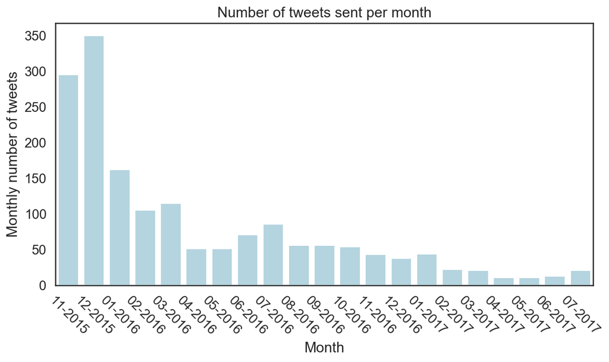

```python
# The default is to plot the mean across subgroups, so use np.sum.
g = sns.barplot(x='Month', y = 'tweet_count', data=tf,
               color='lightblue', estimator=np.sum, ci=None)
g.set(ylabel='Monthly number of tweets')
g.set_title('Number of tweets sent per month')
plt.xticks(rotation='-45');
```

There was a peak in the first few months at over 300 tweets per month, probably due to the novelty. There are of course many more followers (millions) who do not tweet pictures. The counts here are only for original tweets that are still in the online twitter archive (have media files) and partially filtered to remove non-dog pictures (though many remain!).

### Q2. How does the number of each dog stage vary over time?

Taking a look at the number of each dog stage (or Unknown where no stage was mentioned), we can see that most tweets do not include a dog stage:

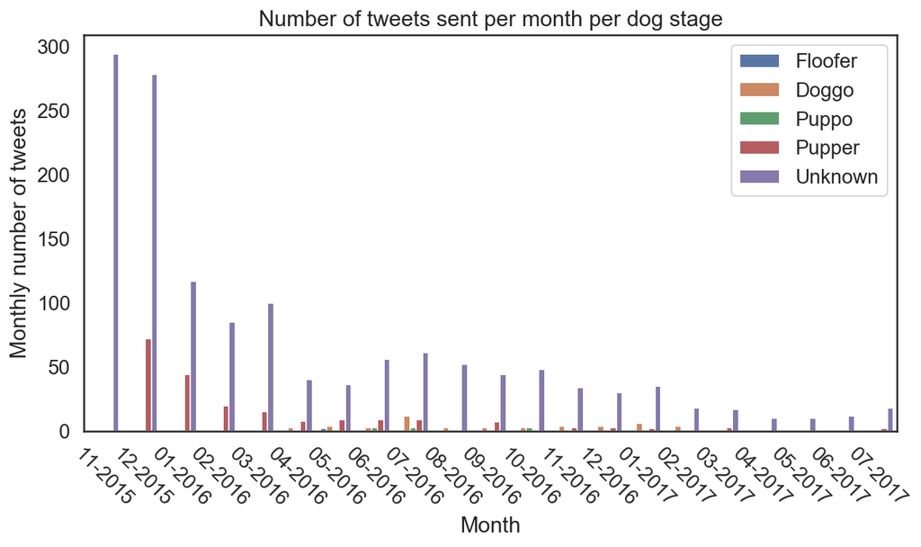

```python
g = sns.barplot(x='Month', y = 'tweet_count', data=tf,
               hue='rate_type', ci=None)
g.set(ylabel='Monthly number of tweets')
g.set_title('Number of tweets sent per month per dog stage')
plt.legend(loc='upper right')
plt.xticks(rotation='-45');
```

For the months shown, 83% of tweets did not mention a dog stage.

```python
# Helper function defined at start of this stage.
display(printable_stats_table(df, 'rate_type', 'Dog Stage')
        .style.hide_index().format({'Share (%)': '{:.0%}'}))
```

| Dog Stage | Count | Share (%) |
| --- | --- | --- |
| Unknown | 1396 | 83% |
| Pupper | 211 | 13% |
| Doggo | 49 | 3% |
| Puppo | 15 | 1% |
| Floofer | 6 | 0% |

If we just look at the dog stages, as a percentage of the monthly tweets, we see an interesting pattern:

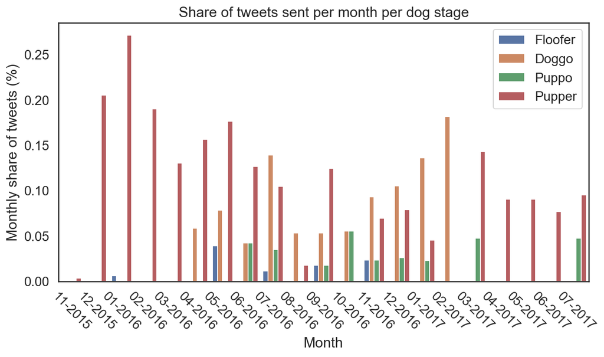

```python
g = sns.barplot(x='Month', y = 'tweet_share', data=tf_stage,
               hue='rate_type', ci=None)
g.set(ylabel='Monthly share of tweets (%)')
g.set_title('Share of tweets sent per month per dog stage')
plt.legend(loc='upper right')
plt.xticks(rotation='-45');
```

In the first months, the dog stage most frequently mentioned was by far 'pupper'. From April 2016, other stages were named. From March 2017, doggos seem to disappear. I wonder why that was, as they were previously increasing.

Let's compare the dog stage shares before and after April 1st 2016:

Dog stage counts prior to April 1st 2016:

```python
display(printable_stats_table(df.query(
    "timestamp < '2016-04-01 00:00:00'"), 'rate_type', 'Dog Stage')
        .style.hide_index().format({'Share (%)': '{:.0%}'}))
```

| Dog Stage | Count | Share (%) |
| --- | --- | --- |
| Unknown | 874 | 85% |
| Pupper | 152 | 15% |
| Floofer | 1 | 0% |
| Puppo | 0 | 0% |
| Doggo | 0 | 0% |

Dog stage counts from April 1st 2016:

```python
display(printable_stats_table(df.query(
    "timestamp >= '2016-04-01 00:00:00'"), 'rate_type', 'Dog Stage')
        .style.hide_index().format({'Share (%)': '{:.0%}'}))
```

| Dog Stage | Count | Share (%) |
| --- | --- | --- |
| Unknown | 522 | 80% |
| Pupper | 59 | 9% |
| Doggo | 49 | 8% |
| Puppo | 15 | 2% |
| Floofer | 5 | 1% |

April 2016 seems to be when using the dog stages took off and perhaps they were around that time 'standardized'.

### Q3. How do the dog stages impact the number of retweets and favorites?

As expected, there is a close relationship between retweet and favorite counts. High counts reflect popular tweets, of course. Some of these were very popular: up to 160k favorites and 80k retweets:

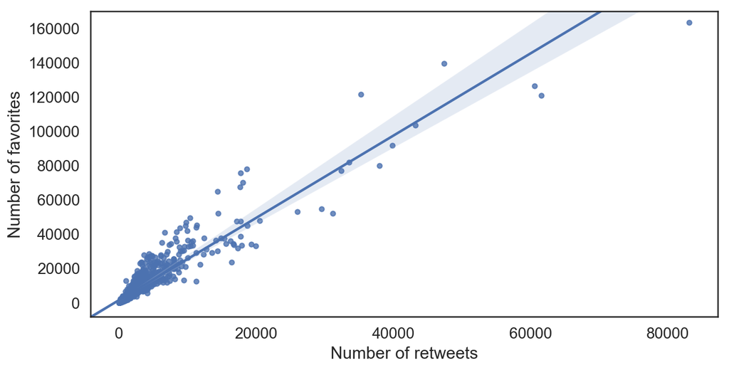

```python
ax = sns.regplot(x='retweet_count', y='favorite_count',
                 scatter_kws={'s':18}, data=df)
ax.set_ylim(-8000, 170000)
ax.set_ylabel('Number of favorites')
ax.set_xlabel('Number of retweets');
```

Let's see how the dog stages are distributed:

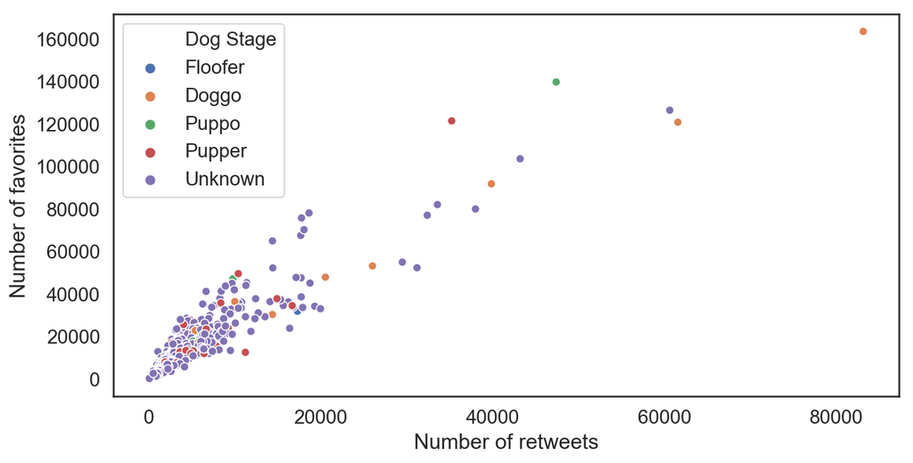

```python
ax = sns.scatterplot(x='retweet_count', y='favorite_count',
                hue='rate_type', data=df)
ax.set_ylabel('Number of favorites')
ax.set_xlabel('Number of retweets')
legend = ax.legend()
legend.texts[0].set_text('Dog Stage');
```

If we filter out the unknowns, we can see the dog stages more clearly:

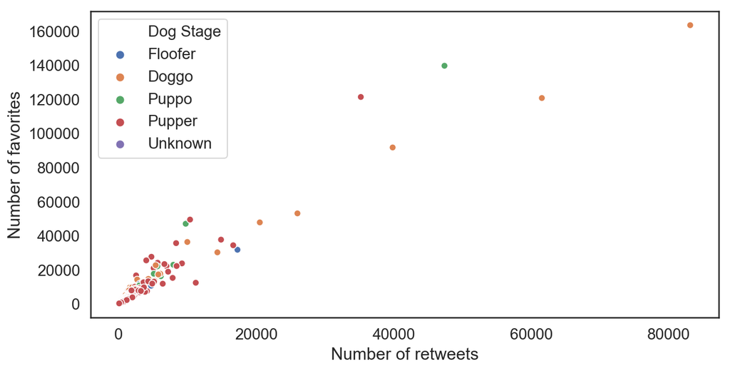

```python
ax = sns.scatterplot(x='retweet_count', y='favorite_count',
                hue='rate_type', data=df.query('rate_type != "Unknown"'))
ax.set_ylabel('Number of favorites')
ax.set_xlabel('Number of retweets')
legend = ax.legend()
legend.texts[0].set_text('Dog Stage');
```

You can view the top 3 tweets in this graphic here:

[Gold medal doggo](https://twitter.com/dog_rates/status/744234799360020481/video/1)  
[Silver medal doggo](https://twitter.com/dog_rates/status/807106840509214720/video/1)  
[Bronze medal puppo](https://twitter.com/dog_rates/status/822872901745569793/photo/1)

The Gold and Silver doggos were videos, which explains their popularity. Let's look at the same graphic but coded with media type.

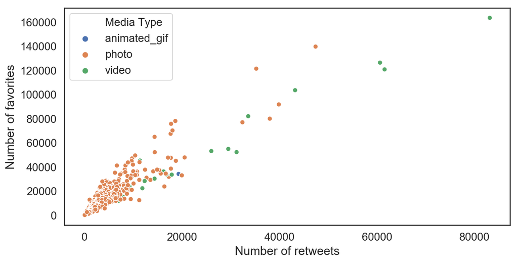

```python
ax = sns.scatterplot(x='retweet_count', y='favorite_count',
                hue='image_type', data=df)
ax.set_ylabel('Number of favorites')
ax.set_xlabel('Number of retweets')
legend = ax.legend()
legend.texts[0].set_text('Media Type');
```

We could take a quick look at retweets and favorites for each of the media types (photo - up to 4 per tweet, a video or an animated gif). Here are the [medians](https://en.wikipedia.org/wiki/Median) (rather than means, which are more infuenced by large outliers):

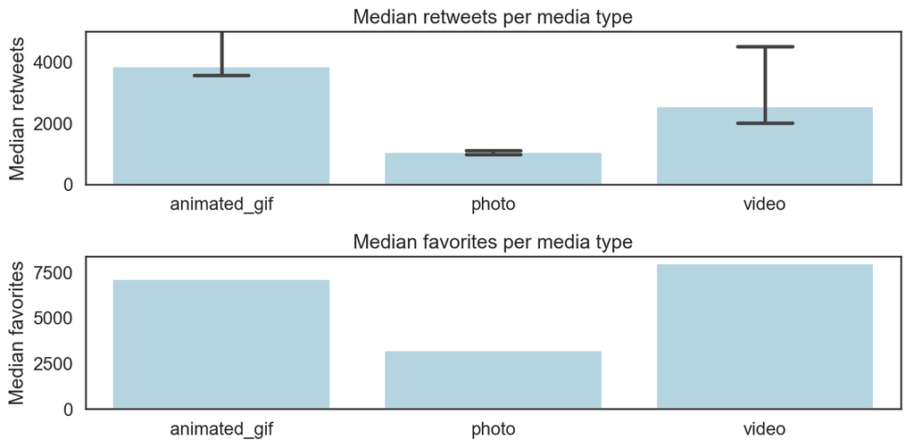

```python
# Helper function defined at start.
values_by_category(df, 'image_type',
                    'Median retweets per media type',
                    'retweet_count', 'Median retweets',
                   np.median,
                    'Median favorites per media type',
                    'favorite_count', 'Median favorites',
                   np.median,
                   ci2='No error bars',
                   ylim1=(0,5000),
                    bar_color='lightblue')
```

```python
display(printable_stats_table(df, 'image_type', 'Media Type')
        .style.hide_index().format({'Share (%)': '{:.1%}'}))
```

| Media Type | Count | Share (%) |
| --- | --- | --- |
| photo | 1612 | 96.1% |
| video | 62 | 3.7% |
| animated_gif | 3 | 0.2% |

So, no surprise that videos and animated gifs get twice the number of retweets and favorites compered to photos. But there were only 3 gifs.

I compared the dog stages using a [Box Plot](https://en.wikipedia.org/wiki/Box_plot) where the centerline of the box is the median. The median shows the center of the distribution better than the mean due to the presence of large outliers, which would make the mean artificially high. Note that I zoomed in to exclude a lot of the outliers.

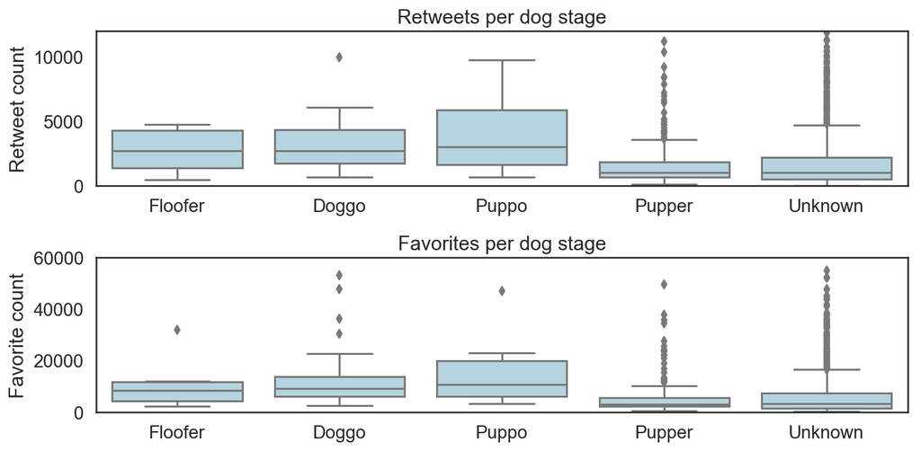

```python
fig = plt.figure()
ax1 = fig.add_subplot(211)
ax1.set_title(label='Retweets per dog stage')
ax1.set(ylim=(0, 12000));
ax2 = fig.add_subplot(212)
ax2.set_title(label='Favorites per dog stage')
ax2.set(ylim=(0, 60000));
sns.boxplot(y='retweet_count', x='rate_type', color="lightblue",
            ax=ax1, data = df)
ax1.set_xlabel('')
ax1.set_ylabel('Retweet count')
sns.boxplot(y='favorite_count', x='rate_type', color="lightblue",
            ax=ax2, data = df)
ax2.set_xlabel('')
ax2.set_ylabel('Favorite count')
plt.tight_layout();
```

At first glance it looks as though the stage pupper is much less popular than the other dog stages, which is counterintuitive: who could resist retweeting a cute puppy?

We have already seen that a large proportion of the pupper tweets were during a time when there was a much higher volume of tweets but also when there were fewer followers who could retweet or favorite. So let's look that the two time periods up until and from April 1st 2016.

First looking at the whole time period (the error bars in all bar charts show the 95% confidence intervals):

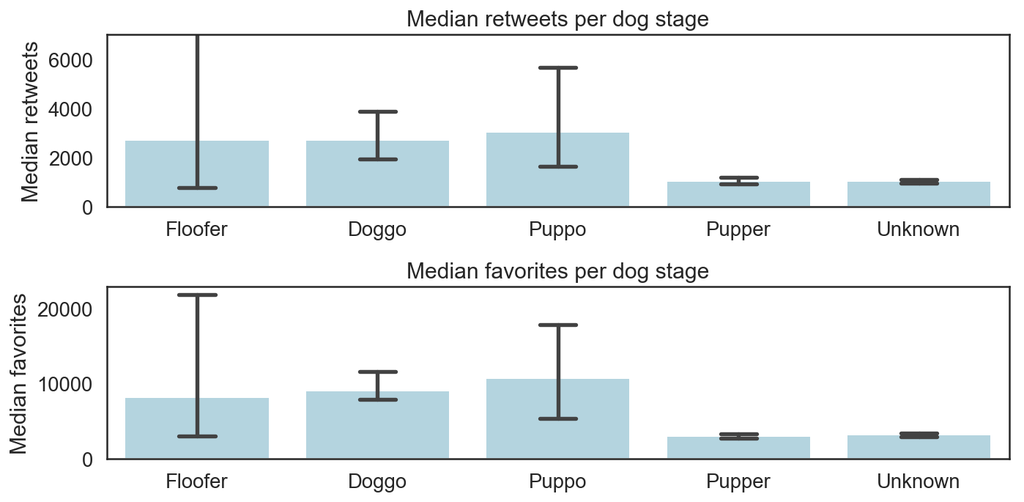

```python
values_by_category(df, 'rate_type',
                    'Median retweets per dog stage',
                    'retweet_count', 'Median retweets',
                   np.median,
                    'Median favorites per dog stage',
                    'favorite_count', 'Median favorites',
                   np.median,
                   ylim1=(0,7000),
                    bar_color='lightblue')
```

That confirms what we saw in the box plots. Now let's look at the period up until April 1st 2016, where there were no doggos or puppos and only 1 floofer (so no error bar for floofer):

[figure not shown]

```python
values_by_category(df.query("timestamp < '2016-04-01 00:00:00'"),
                   'rate_type',
                   'Median retweets per dog stage from April 1st 2016',
                   'retweet_count',  'Median retweets',
                   np.median,
                   'Median favorites per dog stage from April 1st 2016',
                   'favorite_count', 'Median favorites',
                   np.median,
                   bar_color='lightblue')
```

So for this period, puppers tended to get more retweets and favorites than tweets that did not name a stage. Puppies are cute after all! Now Let's look at the period from April 1st 2016:

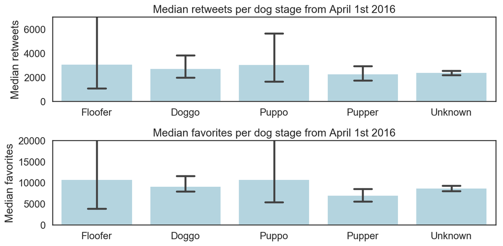

```python
values_by_category(df.query("timestamp >= '2016-04-01 00:00:00'"),
                   'rate_type',
                   'Median retweets per dog stage from April 1st 2016',
                   'retweet_count', 'Median retweets',
                   np.median,
                   'Median favorites per dog stage from April 1st 2016',
                   'favorite_count', 'Median favorites',
                   np.median,
                   ylim1=(0, 7000), ylim2=(0, 20000),
                   bar_color='lightblue')
```

In this period, the median retweets and favorites for pupper are still a little lower but the difference is not as large. Looking at this graphic, I would conclude that there are no really significant differences between the dog stages after they were introduced. But why is pupper a little lower? Doggos had 18% videos compared to 10% puppers and at the same time higher counts per video on average. So that would tend to lower the pupper median compared to doggo.

### Q4. How do the dog stages impact the dog ratings?

The ratings above 10/10 are one of the most charming ideas behind We Rate Dogs. Let's take a look at how the ratings are distributed. The first number (numerator) is on the x-axis (categories, not scaled) and the second number (denominator) is on the y-axis. Most are out of 10, but there are exceptions. (I put a little jitter on the many ratings out of 10).

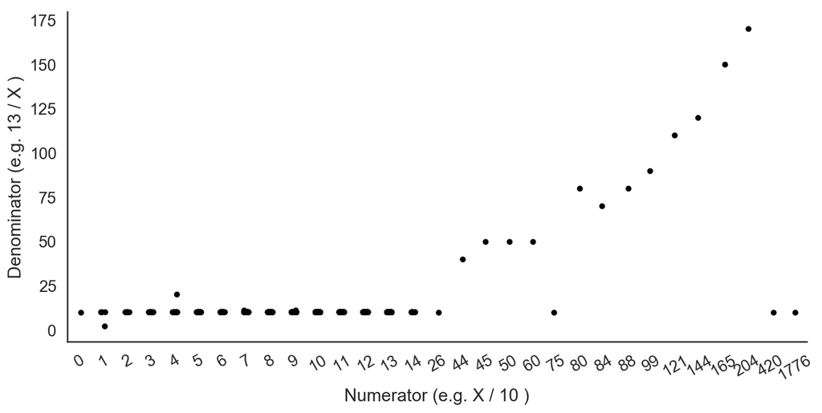

```python
ax = sns.catplot(x='rating_numerator', y='rating_denominator',
                aspect=2, color='black', data=df)
ax.set(xlabel='Numerator (e.g. X / 10 )',
       ylabel='Denominator (e.g. 13 / X )')
ax.set_xticklabels(rotation=30);
```

Some of the higher ratings are because the rating out of 10 was multiplied by the number of dogs in the picture. So 12/10 for 5 dogs becomes 60/50.

To remove the more extreme ratings and provide some normalization, only denominators of 10 and numerators less than 30 will be analysed further. Then the mean numerator scores can be examined.

```python
df_standard = df.query(
    '(rating_denominator == 10)&(rating_numerator < 30)').copy()
```

```python
df_standard.index = df_standard['timestamp']
numerator_frequency = df_standard.groupby(
    pd.Grouper(freq='MS'))[['rating_numerator']].mean().reset_index()
numerator_frequency['Month'] = numerator_frequency.timestamp.map(
    lambda x: x.strftime('%m-%Y'))

# Delete August 2017 which is incomplete.
numerator_frequency = numerator_frequency.query('timestamp < "2017-08-01"')
```

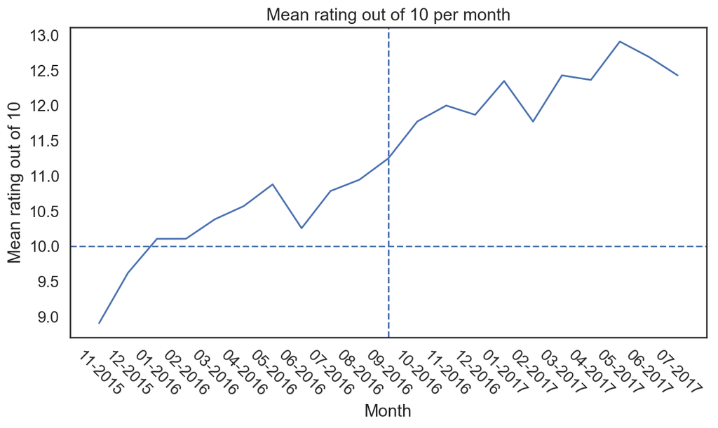

```python
ax = sns.lineplot(x='Month', y='rating_numerator', sort=False,
             data=numerator_frequency)
ax.set(ylabel='Mean rating out of 10')
ax.set_title('Mean rating out of 10 per month')
ax.axhline(10, ls='--')
ax.axvline('09-2016', ls='--')
plt.xticks(rotation='-45');
```

Looking at "standard" ratings out of 10, and including only ratings below 30, the mean rating (mean of the numerator) has been increasing steadily from the start, and passed beyond a mean of 10 (the horizontal dashed line) already in the 3rd month. The "they're good dogs, Brent" tweet defending the unique scoring was made on 12 September 2016, shown by the vertical dashed line, when the mean scores were ca. 11.3 out of 10.

One hypothesis would be that the dogs are getting gooder over time. No? Ok, another would be that there is a continuous 'norming' of the scores such that in August 2017, 13/10 was the new norm. It would be interesting to see if there is a relation between these ratings and the dog types.

```python
cnt = df_standard.groupby(['rate_type'])['rating_numerator']\
    .mean().to_frame().reset_index()
cnt.rename(columns = {'rate_type':'Dog Stage',
                      'rating_numerator':'Mean rating out of 10'},
           inplace = True)

display(cnt.style.hide_index().format(
    {'Mean rating out of 10': '{:,.2f}'}))
```

| Dog Stage | Mean rating out of 10 |
| --- | --- |
| Floofer | 11.83 |
| Doggo | 11.54 |
| Puppo | 11.60 |
| Pupper | 10.48 |
| Unknown | 10.20 |

Let's visualize that with some error bars for the mean:

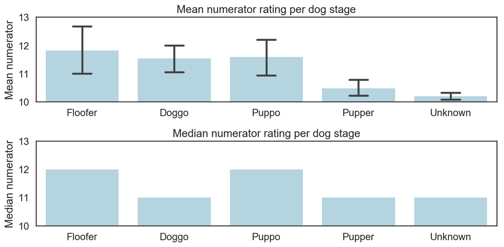

```python
# The error bars for this median did not make sense.
# Any string for ci1 or ci2 will switch off the error bars.

values_by_category(df.query(
    "(rating_denominator == 10)&(rating_numerator < 30)"),
                   'rate_type',
                   'Mean numerator rating per dog stage',
                   'rating_numerator', 'Mean numerator',
                   np.mean,
                   'Median numerator rating per dog stage',
                   'rating_numerator', 'Median numerator',
                   np.median,
                   ylim1=(10,13), ylim2=(10,13),
                   ci2 = 'switch off error bars',
                  bar_color='lightblue')
```

Note that I zoomed the graphic to ratings between 10 and 13. Similar to the retweet and favorite count, all named stages except pupper and the unnamed stages seem to receive higher ratings on average. In case this is again an effect of the early months where pupper was the dominant stage, the ratings from April 1st 2016 are also checked.

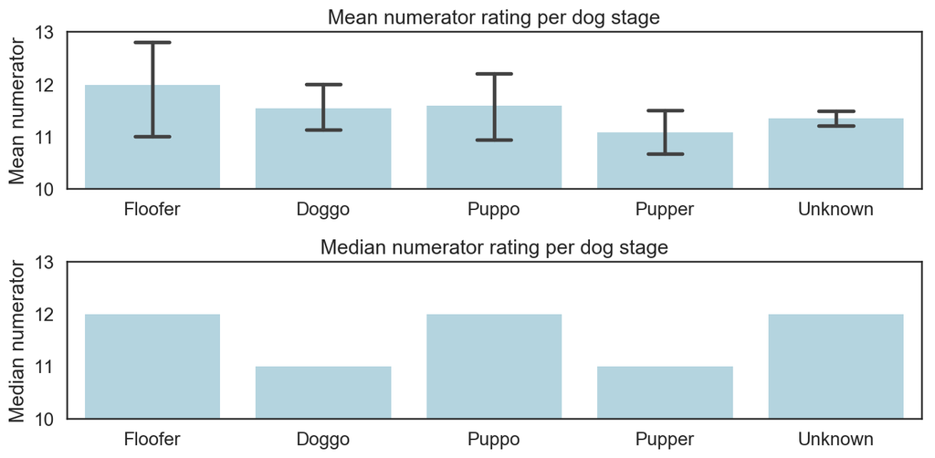

```python
# The error bars for this median did not make sense.
# Error bars switched off by setting estimator parameter to None.

values_by_category(df.query(
    "(rating_denominator == 10)&(rating_numerator < 30)&\
    (timestamp >= '2016-04-01 00:00:00')"),
                   'rate_type',
                   'Mean numerator rating per dog stage',
                   'rating_numerator', 'Mean numerator',
                   np.mean,
                   'Median numerator rating per dog stage',
                   'rating_numerator', 'Median numerator',
                   np.median,
                   ylim1=(10,13), ylim2=(10,13),
                   ci2 = 'switch off error bars',
                  bar_color='lightblue')
```

Again, from April 1st 2016 there was much less distinction of ratings across the different dog types. Due to ratings being lower at a time when the pupper was the predominant named dog type, this has the effect of lowering the mean rating for pupper across the whole timeline. From April 1st 2016, when other dog types appear, there was inadequate evidence of any difference in ratings between the known dog types. If we look at the median ratings, doggos and puppers tended to have 1 point less, i.e. 11/10 compared to 12/10 for floofer, puppo and unknown.

### Q5. How do the dog stages impact the top confidence?

Let's look at the mean and median values of the top prediction confidence that the machine made for each of the dog stages:

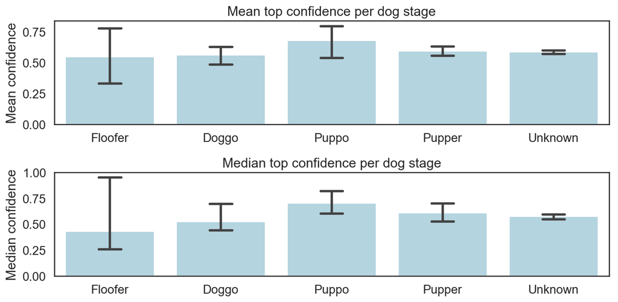

```python
values_by_category(df, 'rate_type',
                   'Mean top confidence per dog stage',
                   'predict_1_confidence', 'Mean confidence',
                   np.mean,
                   'Median top confidence per dog stage',
                   'predict_1_confidence',  'Median confidence',
                   np.median,
                  bar_color='lightblue')
```

There is a tendency for pictures of puppos to receive a higher top prediction confidence. The error bars, representing 95% confidence intervals, show however, that the sample sizes are too low to make clear distinctions.

This is an interesting effect and - if it is really there - it might be explained by certain dog stages having clearer breed characteristics. For example, perhaps a puppo shows these characteristics better than the other stages. However, this is just an idea! More data would be needed to confirm this.

### Q6. What share of the predictions did not recognize a dog and were there really no dogs in the images?

Let's start by looking at the percentage of predictions that were identified as dogs (whether or not the prediction was any good) for the top confident prediction (#1), and second (#2) and third (#3) most confident

```python
presults = {'Prediction rank': ['#1', '#2', '#3', '#1 or #2 or #3'],
            'Share of recognized dogs': [df.predict_1_is_dog.mean(),
                                         df.predict_2_is_dog.mean(),
                                         df.predict_3_is_dog.mean(),
                                        (df.predict_1_is_dog |
                                         df.predict_2_is_dog |
                                         df.predict_3_is_dog).mean()]}

display(pd.DataFrame.from_dict(presults).style.hide_index().format(
    {'Share of recognized dogs': '{:2.1%}'}))
```

| Prediction rank | Share of recognized dogs |
| --- | --- |
| #1 | 73.2% |
| #2 | 74.3% |
| #3 | 71.9% |
| #1 or #2 or #3 | 83.8% |

So around 25 to 30% of the predictions were not for dogs, and around 16% predicted no dogs. Using some examples, let's look at some reasons why this might happen. (The predicted objects and their confidence scores are ordered from high to low).

##### Reason 1: too little dog.

Example 1 predicted Orange (10%), Bagel (9%), Banana (8%).

Example 2 predicted Teapot (98%), Cup (1%), Coffeepot (0%).

Example 3 predicted Bakery (74%), Saltshaker (5%), Teddy (5%).

```python
image_list = []
image_list.append(df.query('tweet_id == 892420643555336193')
                  .iloc[0].url_most_confident_image)
image_list.append(df.query('tweet_id == 840370681858686976')
                  .iloc[0].url_most_confident_image)
image_list.append(df.query('tweet_id == 793135492858580992')
                  .iloc[0].url_most_confident_image)
Images(image_list, header=['Example 1 (too little dog)',
                           'Example 2 (too little dog)',
                           'Example 3 (too little dog)'])
```

[output not shown]

You've got to give the machine enough content to work with!

Note that the predictions do not add up to 100%. Sometimes when the output stage of a neural network applies a so-called 'softmax' function, it forces the categories to add up to 100%. But that divides the 'confidence' evenly across all categories, which may not make sense. The machine might not have 'confidence' in any of its predictions. There are plenty of images in the dataset where the predictions do indeed add up to 100%, but not all. The approach used in this machine learning solution do not require a 100% total and so reflect closer the 'confidence' in the prediction.

##### Reason 2: too much competition with easily recognized objects.

Example 4 predicted Tennis Ball (71%), Kelpie (11%), Malinois (6%).

Example 5 predicted Seat Belt (95%), Toy Terrier (4%), Beagle (0%).

Example 6 predicted Hotdog (83%), Rottweiler (7%), Labrador Retriever (5%).

```python
image_list = []
image_list.append(df.query('tweet_id == 850145622816686080')
                  .iloc[0].url_most_confident_image)
image_list.append(df.query('tweet_id == 670427002554466305')
                  .iloc[0].url_most_confident_image)
image_list.append(df.query('tweet_id == 709042156699303936')
                  .iloc[0].url_most_confident_image)
Images(image_list, header=['Example 4 (competition!)',
                           'Example 5 (competition!)',
                           'Example 6 (competition!)'])
```

[output not shown]

Tennis balls, seatbelts, hotdogs and any easily recognizable object gets the most confidence, even if there are few other distractions. Or maybe we asked the machine to look for 'dogs' and... no, just kidding.

##### Reason 3: too much fun.

Example 7 predicted Ski Mask (98%), Chihuahua (1%), Kelpie (0%).

Example 8 predicted Bow Tie (53%), Sunglasses (8%), Sunglass (5%)

Example 9 predicted Teddy (59%), Jigsaw Puzzle (3%), Doormat (2%).

```python
image_list = []
image_list.append(df.query('tweet_id == 673342308415348736')
                  .iloc[0].url_most_confident_image)
image_list.append(df.query('tweet_id == 749981277374128128')
                  .iloc[0].url_most_confident_image)
image_list.append(df.query('tweet_id == 824297048279236611')
                  .iloc[0].url_most_confident_image)
Images(image_list, header=['Example 7 (too much fun)',
                           'Example 8 (too much fun)',
                           'Example 9 (too much fun)'])
```

[output not shown]

Really a sub-category of 'too little dog' where there is plenty of dog but the machine cannot see through the 'disguise'.

##### Reason 4: too similar to something else.

Example 10 predicted Teddy (97%), Toy Poodle (1%), Chow (0%).

Example 11 predicted Long-Horned Beetle (61%), Ox (3%), Rhinoceros Beetle (3%).

Example 12 predicted Dough (81%), Bakery (3%), French Loaf (2%)

```python
image_list = []
image_list.append(df.query('tweet_id == 785927819176054784')
                  .iloc[0].url_most_confident_image)
image_list.append(df.query('tweet_id == 775733305207554048')
                  .iloc[0].url_most_confident_image)
image_list.append(df.query('tweet_id == 675501075957489664')
                  .iloc[0].url_most_confident_image)
Images(image_list, header=['Example 10 (mistaken identity)',
                           'Example 11 (mistaken identity)',
                           'Example 12 (mistaken identity)'])
```

[output not shown]

These are understandable mistakes. I love example 11: a happy mistake! I had to look at example 12 a while to gather enough faith that it really is a dog.

##### Reason 5: it really isn't a dog.

Example 13 predicted Radio Telescope (16%), Dam (15%), Crane (10%)

Example 14 predicted Espresso (43%), Coffee Mug (42%), Cup (9%)

Example 15 predicted Dogsled (43%), Cocker Spaniel, Chihuahua (7%)

```python
image_list = []
image_list.append(df.query('tweet_id == 760252756032651264')
                  .iloc[0].url_most_confident_image)
image_list.append(df.query('tweet_id == 711968124745228288')
                  .iloc[0].url_most_confident_image)
image_list.append(df.query('tweet_id == 689599056876867584')
                  .iloc[0].url_most_confident_image)
Images(image_list, header=['Example 13 (not a dog)',
                           'Example 14 (not a dog)',
                           'Example 15 (not a dog)'])
```

[output not shown]

Humans would probably still say: "it's a dog!"

The machine does a pretty good job at identifying images, and also in predicting even the breed of dog. It has a much harder time dealing with multiple elements in the image.

One final dog rating just has to be made. I used the python library seaborn to create the graphics here. The author of seaborn included a special plot type that can be run in python after `install seaborn as sns` by using the command `sns.dogplot()`. I give this good doggo a 15/10!

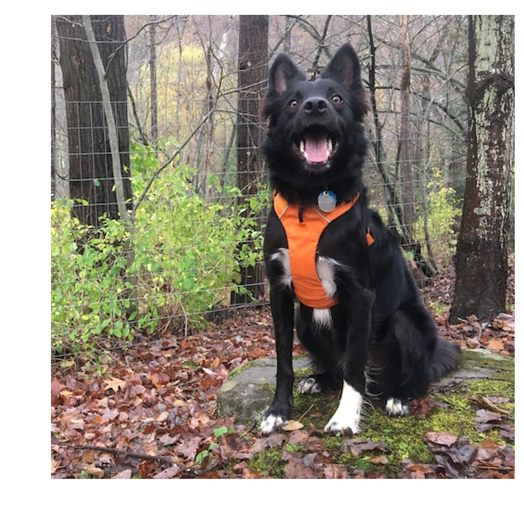

```python
sns.dogplot()
```